# Analyses of beta diversity

Jeff Powell

23 September 2019

Here we use the `phyloseq` object called `phy` that we generated during the first chapter and modified in the second chapter. This object has been manipulated to include only OTUs that have been classified as fungi and successfully classified at the phylum level. OTU data were hellinger-transformed and excluded five samples that had low read counts.

# Multivariate analysis options

When analysing multivariate data, you should think very carefully about what it is that you actually want to do. For instance, do you want to know whether there are patterns in the data, what are the important drivers generating patterns in the data, or which variables best represent patterns in the data? Once you have answered this question, it will become much easier to narrow down the possible approaches and identify the specific approach that is best suited to your data.

The choice of analysis can be determined by answering a series of questions:

1. Am I looking for patterns in the data or do I want to make predictions about particular species and the ways in which they covary? For the former, use *ordination* methods (this Chapter). For the latter, use *DESeq2* methods (Chapter 5).
2. For ordination, are my response variables continuous and approximately linear? If so, approaches based on *principal components analysis* (PCA, this Chapter) are appropriate. If not, PCA may still work but this depends on gradient length, meaning the degree of overlap in the response variables among samples (e.g., if species composition, or betadiversity, does not change very much among samples.
3. For nonlinear and/or discrete responses, what might be an appropriate way to calculate the degree that the responses among samples differ? Raw count data may be used to calculate Chi-squared distances and perform *correspondence analysis* (CA, this Chapter). Other data types (e.g., proportions and relative abundances) can be used to calculate various distance indices for *principal coordinates analysis* (PCoA, this Chapter) or converted to ranks for *nonmetric multidimensional scaling* (NMDS, this Chapter).
4. Do I have additional data that may provide insight into the degree of resemblance among samples? If so, use *constrained ordination* (i.e., *redundancy analysis* [RDA], *canonical correspondence analysis* [CCA], *constrained analysis of principle coordinates* [CAP]) to partition variation in the response variables to these additional predictor variables prior to determining how much variation remains unexplained (Chapter 4).
5. If not, or if much of the variation remains unexplained, is there a high level of betadiversity among samples? If so, use *detrended correspondence analysis* (DCA, this Chapter) to account for an ‘arch effect’ in which samples are scored as similar simply due to the shared absence of particular taxa.
6. Do I want to estimate and compare the importance of specific predictor variables and their interactions? If so, use permutation-based approaches such as *permutational MANOVA* (PerMANOVA) to test specific hypotheses (Chapter 4).

## Further reading

- Mike Palmer maintains a [website](http://ordination.okstate.edu) that is helpful to get an overview of the many approaches that are available and the definitions of terms related to these approaches. The `GUSTA ME` project ([GUide to STatistical Analysis in Microbial Ecology](http://mb3is.megx.net/gustame/home)) includes accessible descriptions of multivariate statistical methods and worked examples (including flow charts) from the microbial ecology literature. `The R Book` by Michael Crawley includes a chapter on these methods that is also accessible to environmental scientists. For detailed discussion, see `Numerical Ecology` by Legendre and Legendre.
- There are several resources for performing multivariate statistical analysis in `R` and a summary of these can be found at the [Environmentrics](http://cran.r-project.org/web/views/Environmetrics.html) CRAN Task View under the `Ordination`, `Dissimilarity coefficients`, and `Cluster analysis` headings and at the [Multivariate](https://cran.r-project.org/web/views/Multivariate.html) CRAN Task View.
- The [Spatial](http://cran.r-project.org/web/views/Spatial.html) CRAN Task View will also be useful for more complex analysis of univariate and multivariate data with explicit spatial structure.

# Modifying the community matrix

## Trimming samples

We dealt with this topic in Chapter 2. If coverage varies among samples and particularly if coverage is low, we might be concerned that we are overestimating betadiversity and possibly increasing our chances of drawing incorrect conclusions. In cases like this, some recommend randomly resampling the community data at a common level of sampling effort. For the fungal community data described above, we might argue that resampling isn’t necessary because all of our samples have fairly good coverage and, therefore, we have captured most of the species present in each replicate. However, for the sake of convincing the second Reviewer, you might want to use the resampled data in `phy.rar` object that we created in Chapter 2.

## Trimming OTUs

You may also wish to modify your community data to eliminate potentially spurious observations or retain only those observations that clear a pre-defined threshold. This is easy to do once the community table is converted to a matrix, allowing for comparison of inferences based on community data that have or have not been cleaned up.

```r
# create matrix from community dataframe
# 'veganotu' from 'QsRutils' converts successfully to matrix
mat <- veganotu(phy)

# original number of observations in total
sum(mat)
```

```
## [1] 1271389
```

```r
# original number of observations per sample
summary(rowSums(mat))
```

```
##    Min. 1st Qu.  Median    Mean 3rd Qu.    Max.
##   26264   41204   46723   47088   53540   61384
```

```r
# original number of observations per species
summary(colSums(mat))
```

```
##     Min.  1st Qu.   Median     Mean  3rd Qu.     Max.
##      0.0      3.0     14.0    616.9    119.0 103412.0
```

```r
# remove singletons
sing <- mat
sing[mat == 1] <- 0
summary(rowSums(sing))
```

```
##    Min. 1st Qu.  Median    Mean 3rd Qu.    Max.
##   26160   41152   46680   47025   53468   61339
```

```r
summary(colSums(sing))
```

```
##    Min. 1st Qu.  Median    Mean 3rd Qu.    Max.
##       0       2      14     616     118  103412
```

```r
# remove observations that are less than 0.1% of a sample
swap <- mat
swap[mat / rowSums(mat) < 0.001] <- 0
summary(rowSums(swap))
```

```
##    Min. 1st Qu.  Median    Mean 3rd Qu.    Max.
##   25149   39369   43124   44271   51558   57706
```

```r
# remove OTUs with fewer than 10 reads
ltten <- mat[, colSums(mat) >= 10]
summary(colSums(ltten))
```

```
##    Min. 1st Qu.  Median    Mean 3rd Qu.    Max.
##      10      24      76    1085     422  103412
```

```r
# remove OTUs in fewer than five samples
ltfive <- mat[, colSums(decostand(mat, method = 'pa')) >= 5]
summary(colSums(decostand(ltfive, method = 'pa')))
```

```
##    Min. 1st Qu.  Median    Mean 3rd Qu.    Max.
##    5.00    7.00   10.00   12.05   16.00   27.00
```

```r
# remove OTUs that make up less than 0.005% of all reads
rare <- mat[, colSums(mat) / sum(mat) >= 0.00005]
summary(colSums(rare))
```

```
##    Min. 1st Qu.  Median    Mean 3rd Qu.    Max.
##      64     142     361    1969    1282  103412
```

```r
# once you decide which to use, you can reimport back into the 'phyloseq' object
# replace 'mat' with your desired object
otu_table(phy) <- otu_table(mat, taxa_are_rows=F)

# tidy workspace
rm(sing, swap, ltten, ltfive, rare, mat)
```

## Transforming the OTU table

Finally, we may want to transform our OTU data before analysing them. The `decostand` function from `vegan` is an easy option for this. Look at `?decostand` for more options. Alternatively, we might choose to calculate centred log ratios uding the `clr` function from the `compositions` library.

```r
# create matrix from community dataframe
# 'veganotu' from 'QsRutils' converts successfully to matrix
mat <- veganotu(phy)

# convert to relative abundances
relabund <- decostand(mat, method='total')
summary(rowSums(relabund))
```

```
##    Min. 1st Qu.  Median    Mean 3rd Qu.    Max.
##       1       1       1       1       1       1
```

```r
# convert to sqrt-transformed relative abundances
helling <- decostand(mat, method='hellinger')
summary(rowSums(helling))
```

```
##    Min. 1st Qu.  Median    Mean 3rd Qu.    Max.
##   7.404   8.431  10.191  11.030  13.834  15.125
```

```r
# convert to a binary matrix
pa <- decostand(mat, method='pa')
summary(rowSums(pa))
```

```
##    Min. 1st Qu.  Median    Mean 3rd Qu.    Max.
##   244.0   308.0   394.0   382.3   442.0   528.0
```

```r
# convert to a relative ranks
rank <- decostand(mat, method='rrank')
summary(rowSums(rank))
```

```
##    Min. 1st Qu.  Median    Mean 3rd Qu.    Max.
##   122.5   154.5   197.5   191.6   221.5   264.5
```

```r
# convert to centred log ratios
# don't load 'compositions' package as it would hide 'stats::dist'
clrs <- data.frame(compositions::clr(mat))
summary(rowSums(clrs))
```

```
##       Min.    1st Qu.     Median       Mean    3rd Qu.       Max.
## -7.294e-13  3.094e-13  4.843e-13  6.229e-13  1.007e-12  2.180e-12
```

```r
# we will use the hellinger-transformed data later
otu_table(phy) <- otu_table(helling, taxa_are_rows=F)

# tidy workspace (but keep 'clrs' for later)
rm(relabund, helling, pa, rank, mat)
```

# Ordination methods

Unconstrained ordination approaches are very useful for simplifying multivariate data to visualise patterns. These should always be the first step in the analysis of multivariate data, even when you are interested in testing specific hypotheses regarding the potential indicators and drivers of data structure. There are several options, the choice of which to use depends on the characteristics of the data.

1. Principal Components Analysis (PCA) – PCA is ultimately the transformation of continuous multivariate data into new variables that maximise the amount of variance explained in the data, with each subsequent variable orthogonal (think perpendicular but in greater than two dimensions) to the previous variable and explaining decreasing amounts of variation. The new variables are linear combinations of the original variables. Keep in mind that PCA generates linear combinations and that the analysis is sensitive to deviations from normality, as are linear models.

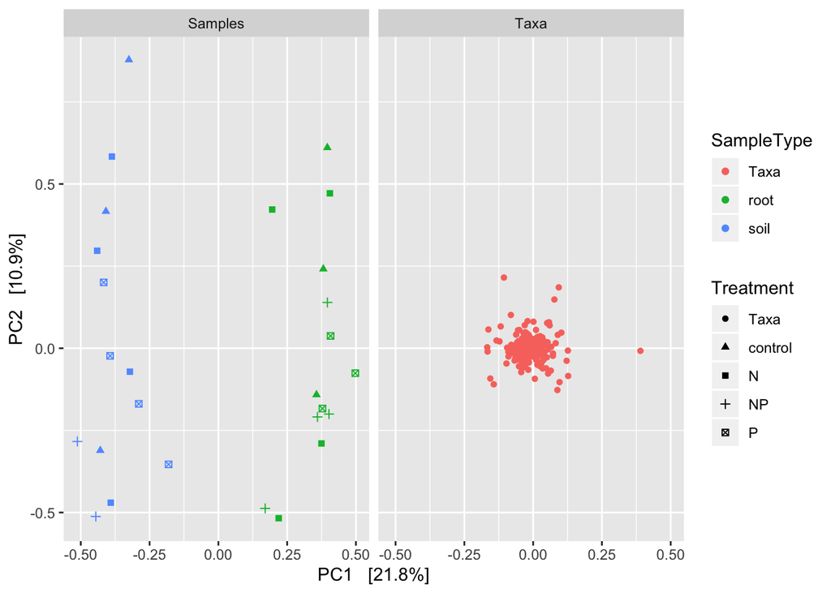

```r
# PCA
plot_ordination(phy, ordinate(phy, method='RDA'), type='split',
                color='SampleType', shape='Treatment')
```

2. Correspondence Analysis (CA) – CA uses a different approach to estimate divergence among samples, based on calculation of $\chi^{2}$ distances as for contingency tables. This property makes CA a better option than PCA for analysing tables of species counts in different environments.

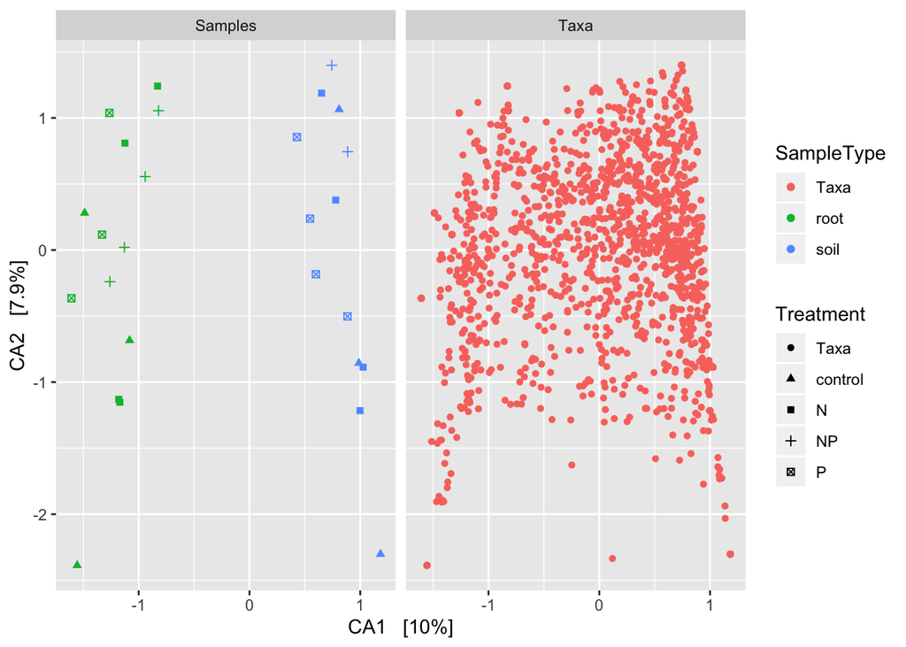

```r
# CA
plot_ordination(phy, ordinate(phy, method='CCA'), type='split',
                color='SampleType', shape='Treatment')
```

3. Detrended Correspondence Analysis (DCA) – DCA is an extension of CA in which variation along the second axis is rescaled to account for high levels of turnover in communities sampled at different points along a long gradient.

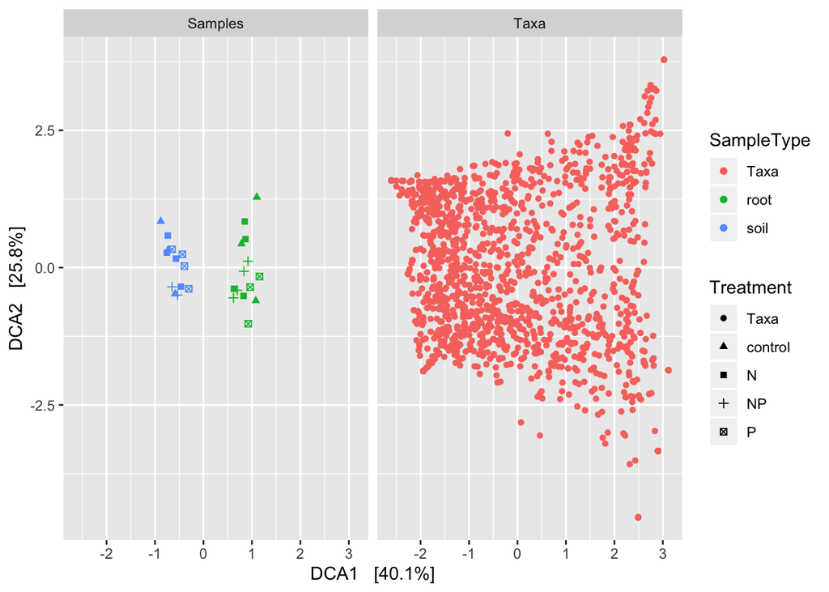

```r
# DCA
plot_ordination(phy, ordinate(phy, method='DCA'), type='split',
                color='SampleType', shape='Treatment')
```

4. Principle Coordinates Analysis (PCoA; also known as Multidimensional Scaling, MDS) – Just as euclidean distances are not appropriate for estimating the divergence between samples when analysing frequency data, some data types require an alternative to $\chi^{2}$ distances. PCoA allows for the analysis of these data using distance matrices estimated from various multidimensional scaling indices. Many common metrics for estimating community dissimilarity are available (for example, see `?dist`, `?vegan::vegdist`, and `?labdsv::dsvdis`).

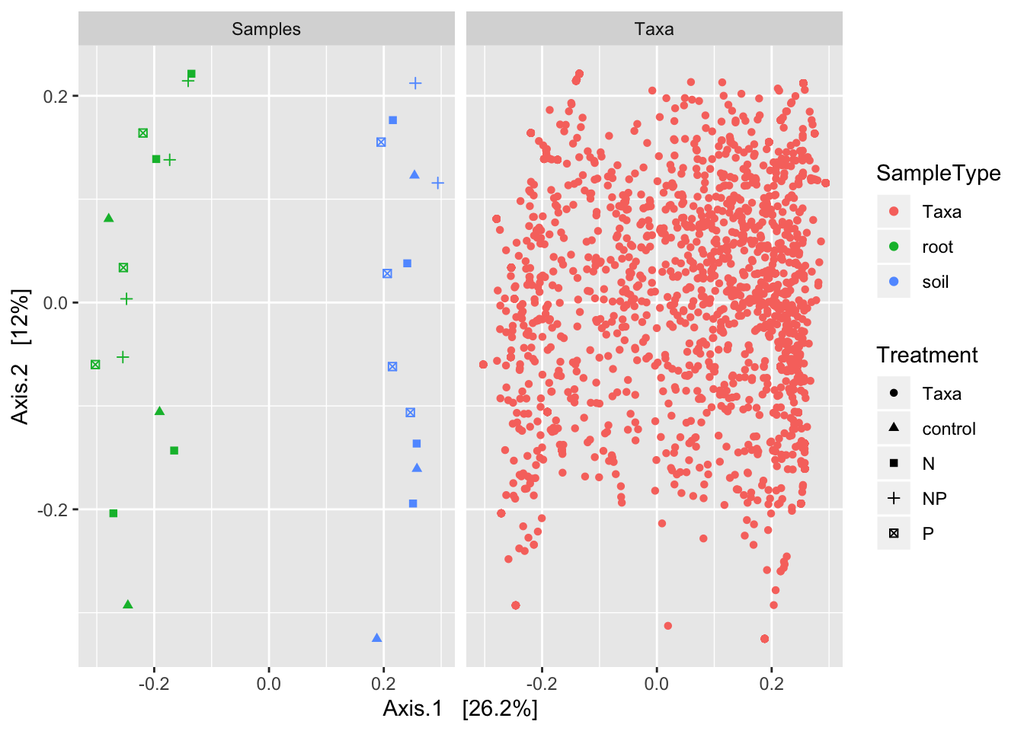

```r
# PCoA
plot_ordination(phy, ordinate(phy, method='PCoA', dist='bray'), type='split',
                color='SampleType', shape='Treatment')
```

5. Nonmetric Multidimensional Scaling (NMDS) – NMDS maximises the differences between samples on few dimensions, which can be particularly useful for visual representation of the dissimilarities between samples. It is ‘nonmetric’ because the data undergo rank-order transformation and their positions are moved during the procedure to minimise stress. The procedure is iterative, and technical data are output to the screen as it runs. `*** Solution reached` should appear at the end of the output; if not, redo the analysis and increase the value associated with the `trymax` argument (the default is 20). If the stress in the final run is less than 0.2, this is acceptable. Stress values greater than 0.3 are unsatisfactory suggesting that the dissimilarities are not effectively captured by these two dimensions. Increase the number of dimensions using the `k` argument (the default is 2).

```
## *** Solution reached
```

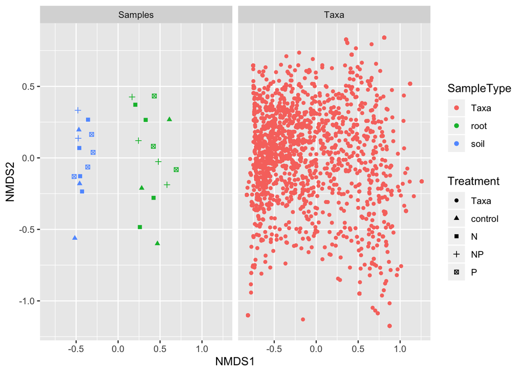

```r
# NMDS
plot_ordination(phy, ordinate(phy, method='NMDS', dist='bray'), type='split',
                color='SampleType', shape='Treatment')
```

## Which one?

We can decide the most appropriate analysis method based on the distribution of ‘sample’ and ‘taxa’ loadings in the ordination. In most cases with microbial community data, the points would be distributed in a highly asymmetical way following PCA and CA, indicating that these methods do a poor job of explaining variation. DCA may be a useful approach in this case, but PCoA and NMDS are favoured especially if additional data have been collected that might explain variation among microbial communities (see below). NMDS may be preferred for visualisation, but PCoA is preferred if wanting to interpret the absolute distances between communities in different samples.

In this case, the result using PCA looks to be pretty good, which may be because all of our samples were collected from a single paddock. We can confirm that PCA might be good for analysis by estimating the length of the gradient in species composition using the `decorana` function.

```r
# estimate gradient lengths for first few axes
summary(decorana(otu_table(phy)), display='none')
```

```
##
## Call:
## decorana(veg = otu_table(phy))
##
## Detrended correspondence analysis with 26 segments.
## Rescaling of axes with 4 iterations.
##
##                   DCA1   DCA2   DCA3   DCA4
## Eigenvalues     0.3445 0.2216 0.1506 0.1431
## Decorana values 0.3454 0.1873 0.1582 0.1110
## Axis lengths    2.0369 2.3041 1.8795 1.6283
```

The gradient length along the first axis is a little more than 2. A rule of thumb is that, since this value is less than 3, PCA would be an appropriate method.

## Distance indices

In other cases, how does one choose one of the available indices for calculating dissimilarity? One way to do so is to pick the index that provides the best rank-order similarity (i.e., nonparametric correlation based on two rank-transformed variables) to the gradient under study, using `rankindex`. This gradient might be represented in an environmental matrix or some other indicator of a putative gradient (e.g., sampling coordinates). Using the continuous variables from our sample data, we might choose to use Manhattan distances.

```r
# compare OTU matrix to the continuous variables from the sample data
rankindex(scale(select_if(sample_data(phy), is.numeric)), otu_table(phy))
```

```
##        euc        man        gow        bra        kul
## 0.10346996 0.19015269 0.14626448 0.07575359 0.08278862
```

Note that `rankindex` could also be used to decide how to standardise the OTU matrix (see above examples with `decostand`).

There has also been a strong push to use centred log ratios with Aitchison distances as input for PCAs (compositional data analysis, Gloor).

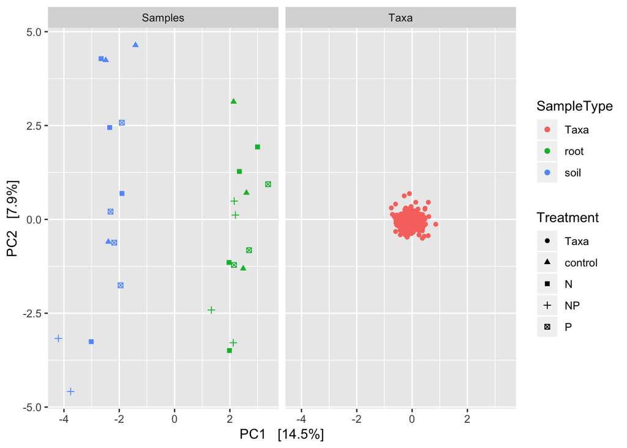

```r
# PCA
plot_ordination(phy, ordinate(otu_table(clrs, taxa_are_rows=F), method='RDA'), type='split',
                color='SampleType', shape='Treatment')
```

We will come back to this in chapter 5.

# Plotting the ordination

Visualising the ordination result is easy using the `plot_ordination` function, as we have already seen. We can also do quite a bit of customisation by adding ggplot2 layers.

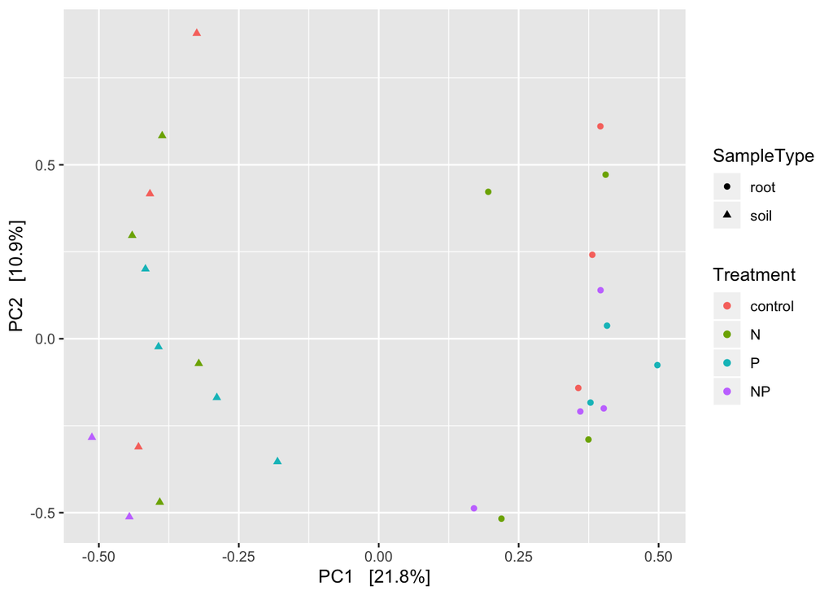

```r
# generate ordination
ord <- ordinate(phy, method='RDA')

# plot loadings using default values
plot_ordination(phy, ord, type='sample',
                color='Treatment', shape='SampleType')
```

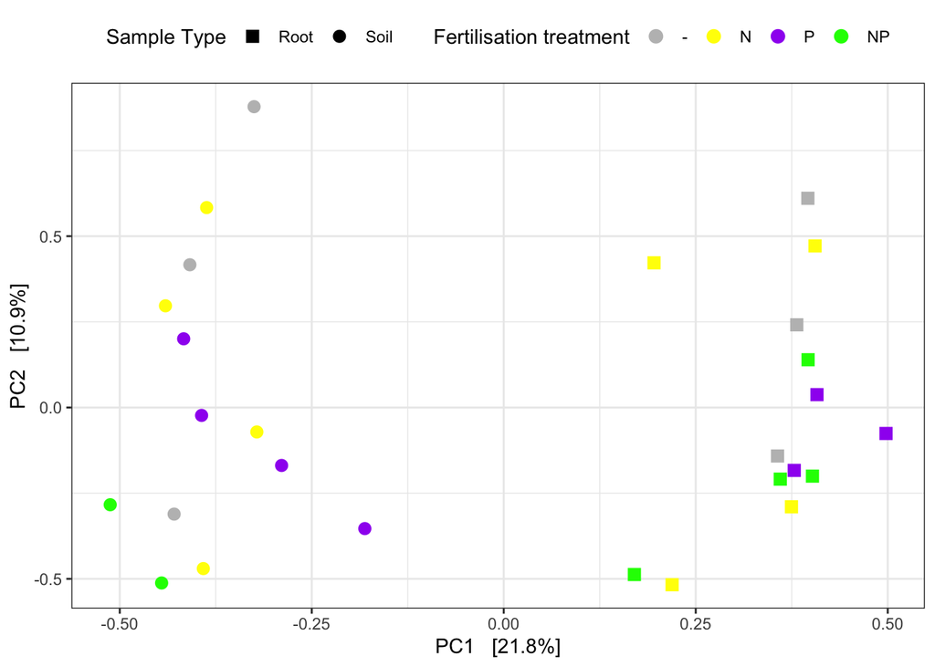

```r
# customise the plot
# most (but not all) can be done by adding ggplot2 layers
p<-plot_ordination(phy, ord, type='sample',
                color='Treatment', shape='SampleType') +
  geom_point(cex=3) +
  scale_color_manual(name='Fertilisation treatment',
                     values=c('grey', 'yellow', 'purple', 'green'),
                     labels=c('-', 'N', 'P', 'NP')) +
  scale_shape_manual(name='Sample Type',
                     values=c(15, 16),
                     labels=c('Root', 'Soil')) +
  theme_bw() +
  theme(legend.position='top')
# modify axis labels
p$labels$x <- gsub('Axis.', 'PC', p$labels$x)
p$labels$y <- gsub('Axis.', 'PC', p$labels$y)
# print plot
p
```

For some patterns we might want to include additional layers highlighting grouping of samples. One option for this is to use the `ggordiplot` library with a result generated using `vegan::rda`.

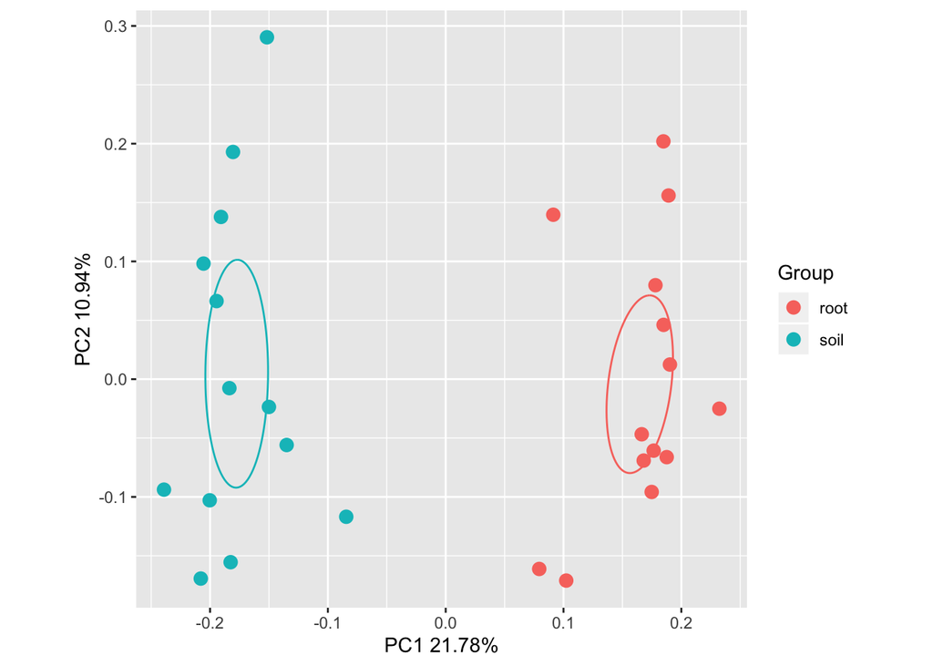

```r
# load library
library(ggordiplots)

# 95% confidence ellipse for centroid
gg_ordiplot(rda(otu_table(phy)), groups=sample_data(phy)$SampleType,
            kind='se', conf=0.95)
```

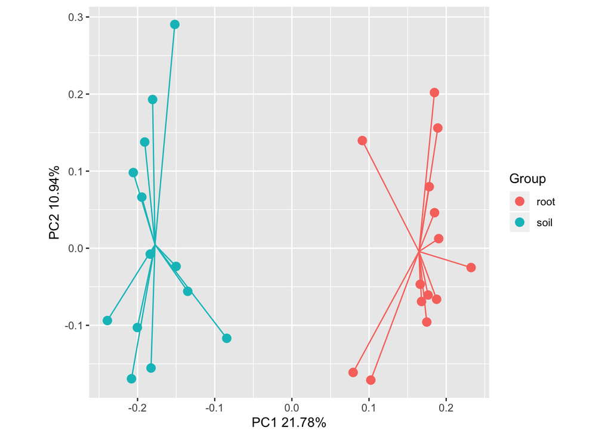

```r
# spider plot
gg_ordiplot(rda(otu_table(phy)), groups=sample_data(phy)$SampleType,
            ellipse=F, spider=T)
```

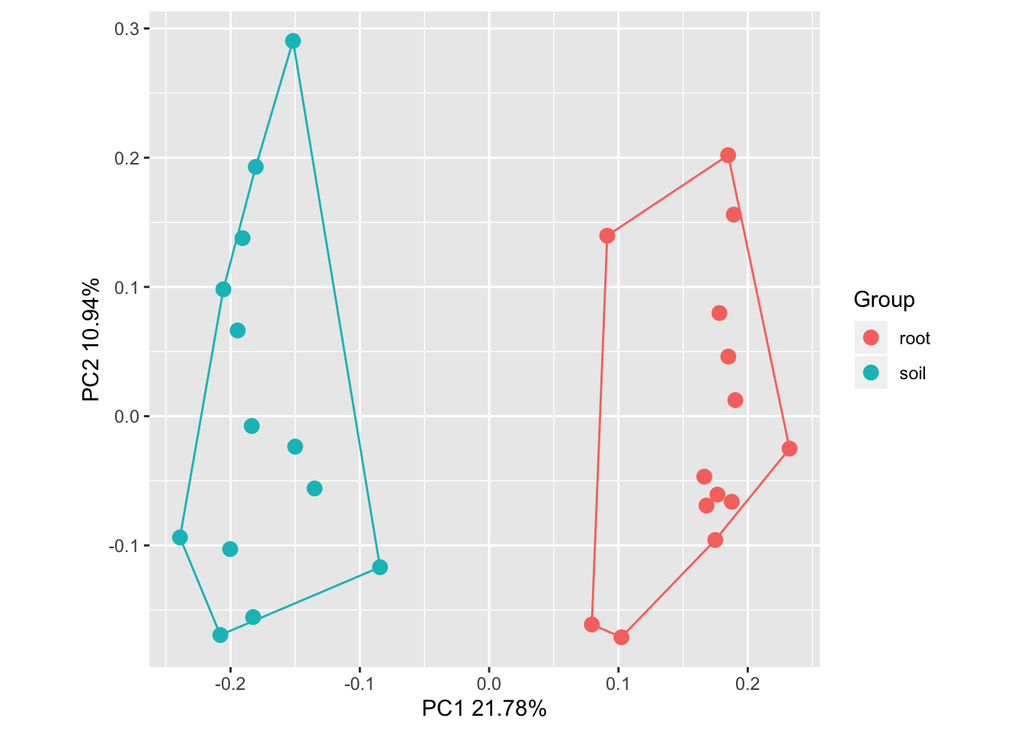

```r
# hull plot
gg_ordiplot(rda(otu_table(phy)), groups=sample_data(phy)$SampleType,
            ellipse=F, hull=T)
```

However, these are very difficult to customise beyond this and they do not work at all for PCoA or NMDS results. Here is an example for how we might produce a plot using base-R functions.

```r
# set up the colour palette
palette(c('grey', 'yellow', 'purple', 'green'))

# create a vector containing all treatment combinations
trts <- with(sample_data(phy), interaction(SampleType, Treatment, sep='-'))
levels(trts)
```

```
## [1] "root-control" "soil-control" "root-N"       "soil-N"
## [5] "root-P"       "soil-P"       "root-NP"      "soil-NP"
```

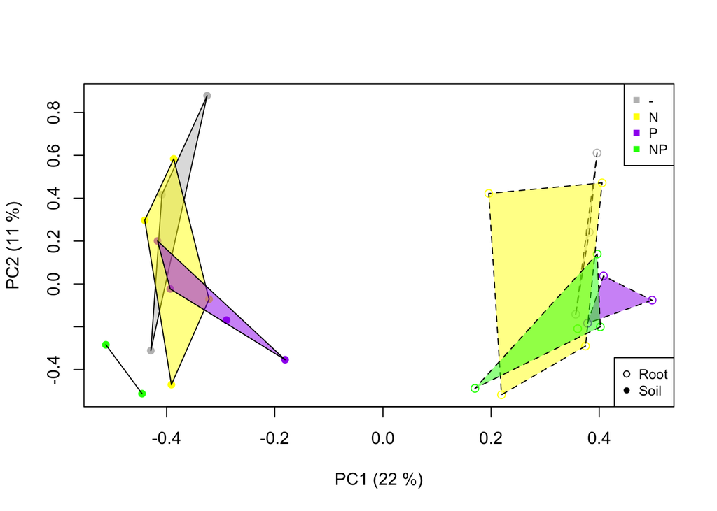

```r
# ordination
ord <- rda(otu_table(phy))

# draw a polygon around all points in a treatment
with(sample_data(phy), plot(scores(ord, display='sites'),  # identifies coordinates
                   pch=c(1,16)[SampleType], col=Treatment,   # assign symbols, colours
                   xlab='PC1 (22 %)', ylab='PC2 (11 %)'))  # change axis labels
legend('topright',  # position the legend for color
       legend=c('-', 'N', 'P', 'NP'),  # set legend text
       pch=rep(15, 4), col=palette(),  # assign symbols and colours
       cex=0.8)  # slightly reduce the size of the text and points
legend('bottomright',  # position the legend for symbols
       legend=c('Root', 'Soil'),  # set legend text
       pch=c(1,16), col='black',  # assign symbols and colours
       cex=0.8)  # slightly reduce the size of the text and points
ordihull(ord, trts, draw='polygon',   # draw polygon
         col=rep(palette(), each=2), lty=rep(c('dashed', 'solid'), 2))
```

Adding a layer using `ordiellipse` or `ordispider` is also an option, just replace the call to `ordihull` with one of these. See the help page for these functions for more infomation.